# High School Seniors t Test

```r
library(tidyverse)
library(DT)
library(pander)
library(readr)
library(car)
library(lattice)
```

```r
HSS <- read_csv("../../Data/HighSchoolSeniors.csv")
HSS2 <- HSS %>%
  drop_na() %>%
  filter(Handed == "Right-Handed" | Handed == "Left-Handed")
#Remember: select "Session, Set Working Directory, To Source File Location", and then play this R-chunk into your console to read the HSS data into R.
```

## Background

I have data from a High School dataset and I want to do an independent sample t-test to see if left handed people have a higher average score in a memory game versus right handed people.

## Questions and Hypotheses

question : Do left handed people have a higher average score in a memory game than right handed people?

- Defining variables:
  $$\mu_1 = \text{the mean memory score for left handed people}$$
  $$\mu_2 = \text{the mean memory score for right handed people}$$

Hypotheses :
$$H_0: \mu_1 - \mu_2 = 0$$

$$H_a: \mu_1 - \mu_2 > 0$$

## Analysis

```r
par(mfrow = c(1,2))
qqPlot(HSS2$Score_in_memory_game[HSS2$Handed=="Left-Handed"], ylab = "left handed")
```

```
## [1] 14 19
```

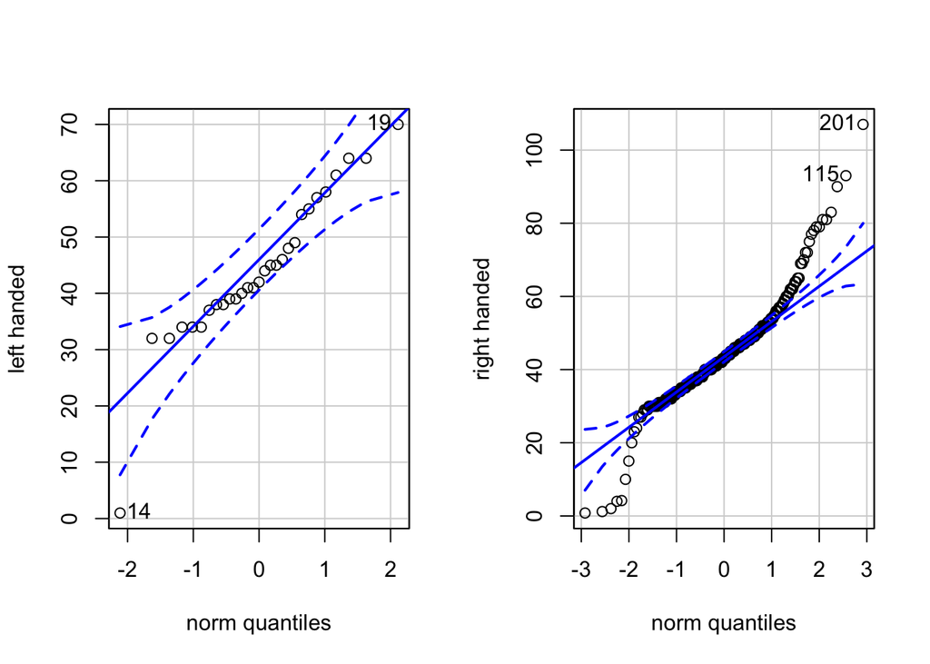

```
## [1] 201 115
```

```r
qqPlot(HSS2$Score_in_memory_game[HSS2$Handed=="Right-Handed"], ylab = "right handed")
```

The some of the data for the right handed memory scores don’t look normal but it’s just a few data points compared to all the rest so we can keep doing our t-test.

```r
test <- t.test(HSS2$Score_in_memory_game[HSS2$Handed=="Left-Handed"],
               HSS2$Score_in_memory_game[HSS2$Handed=="Right-Handed"],
       data = HSS2,
       mu = 0,
       alternative = "greater",
       conf.level = 0.95)

pander(test)
```

Welch Two Sample t-test: `HSS2$Score_in_memory_game[HSS2$Handed == "Left-Handed"]` and `HSS2$Score_in_memory_game[HSS2$Handed == "Right-Handed"]`

| Test statistic | df | P value | Alternative hypothesis | mean of x | mean of y |
| --- | --- | --- | --- | --- | --- |
| 0.0006859 | 34.04 | 0.4997 | greater | 44.21 | 44.2 |

I’m going to use an alpha value of 0.05 here. I see that the p value is 0.4997 which is well above our alpha so it looks like we can reject the alternative hypothesis that left handed people have a highter average score in the memory game than right handed people.

## Graphical Summary

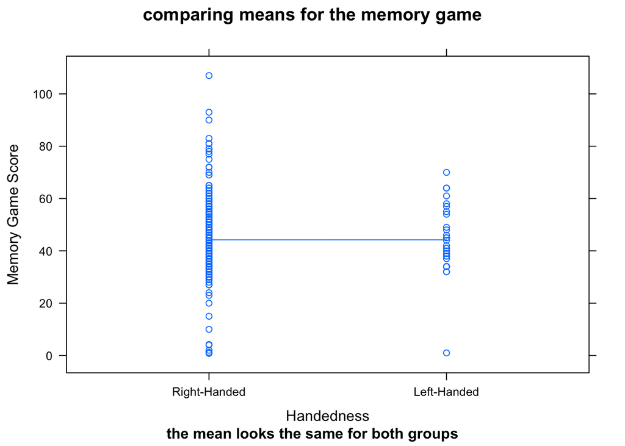

```r
xyplot(Score_in_memory_game ~ as_factor(Handed), data = HSS2, type=c("p","a"), main = "comparing means for the memory game", xlab = "Handedness", ylab = "Memory Game Score", sub = "the mean looks the same for both groups")
```

## Interpretation and Conclusion

Here we can see visually that the means look the relatively the same for both left and right handed people for the memory score. So according to this and our t-test there is no significant difference in the memory of left and right handed people.